# HW2

Henry Tran

4/19/2023

4.8.1: Image will be uploaded alongside this R markdown file.

4.8.4.b:

```
## [1] 0.00950625
```

4.8.4.c:

```
## [1] 7.951729e-102
```

4.8.4.d: As p increases, the fraction of observations near any point goes to 0. 4.8.4.e: For p = 1, it would be 0.1. When p = 2, it would be (0.1)^(1/2) = 0.316 When p = 100, it comes out to (0.1)^(1/100) = 0.977 As p increases, length becomes closer to 1.

4.8.12.a:

Log odds of orange vs. apple in my model is $\beta + \beta_1x$ (please imagine there being hats over the betas. I can’t get the latex to work).

4.8.12.b: Log odds of orange vs. apple in my friend’s model is (alpha_orange0 - alpha_apple0) + (alpha_orange1 - alpha_orange1)x. (alphas have hats).

4.8.12.c: (alpha_orange0 - alpha_apple0) = 2 (alpha_orange1 - alpha_orange1) = -1

4.8.12.d: (1.2-3) = -1.8. This is for beta 0 hat. (-2-0.6) = -2.6. This is for beta 1 hat.

4.8.12.e: They should agree all the time because your friend’s coefficients are just reparameterizations of your own coefficients.

```
##       Year           Lag1               Lag2               Lag3
##  Min.   :1990   Min.   :-18.1950   Min.   :-18.1950   Min.   :-18.1950
##  1st Qu.:1995   1st Qu.: -1.1540   1st Qu.: -1.1540   1st Qu.: -1.1580
##  Median :2000   Median :  0.2410   Median :  0.2410   Median :  0.2410
##  Mean   :2000   Mean   :  0.1506   Mean   :  0.1511   Mean   :  0.1472
##  3rd Qu.:2005   3rd Qu.:  1.4050   3rd Qu.:  1.4090   3rd Qu.:  1.4090
##  Max.   :2010   Max.   : 12.0260   Max.   : 12.0260   Max.   : 12.0260
##       Lag4               Lag5              Volume            Today
##  Min.   :-18.1950   Min.   :-18.1950   Min.   :0.08747   Min.   :-18.1950
##  1st Qu.: -1.1580   1st Qu.: -1.1660   1st Qu.:0.33202   1st Qu.: -1.1540
##  Median :  0.2380   Median :  0.2340   Median :1.00268   Median :  0.2410
##  Mean   :  0.1458   Mean   :  0.1399   Mean   :1.57462   Mean   :  0.1499
##  3rd Qu.:  1.4090   3rd Qu.:  1.4050   3rd Qu.:2.05373   3rd Qu.:  1.4050
##  Max.   : 12.0260   Max.   : 12.0260   Max.   :9.32821   Max.   : 12.0260
##  Direction
##  Down:484
##  Up  :605
##
##
##
##
```

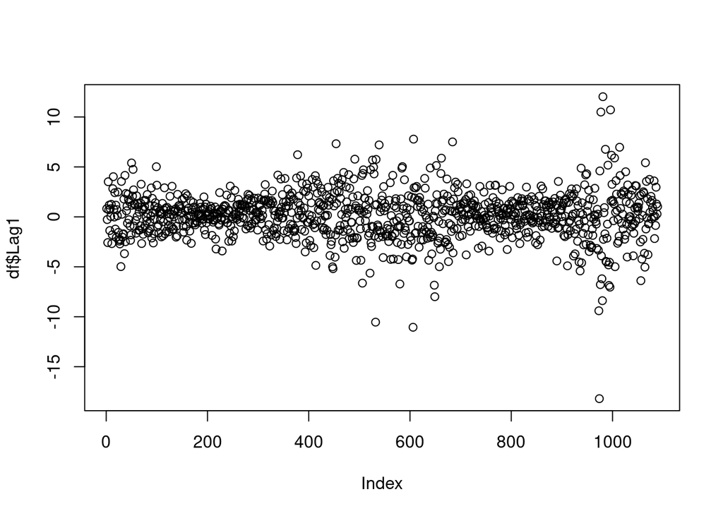

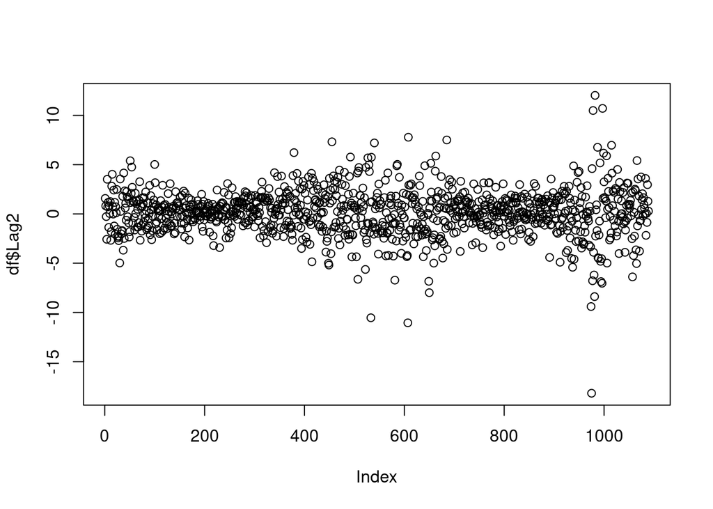

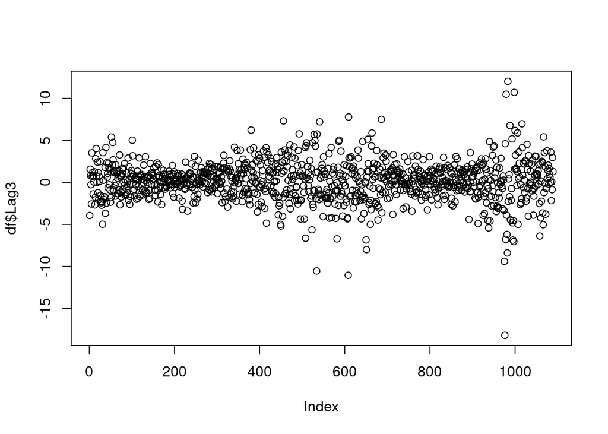

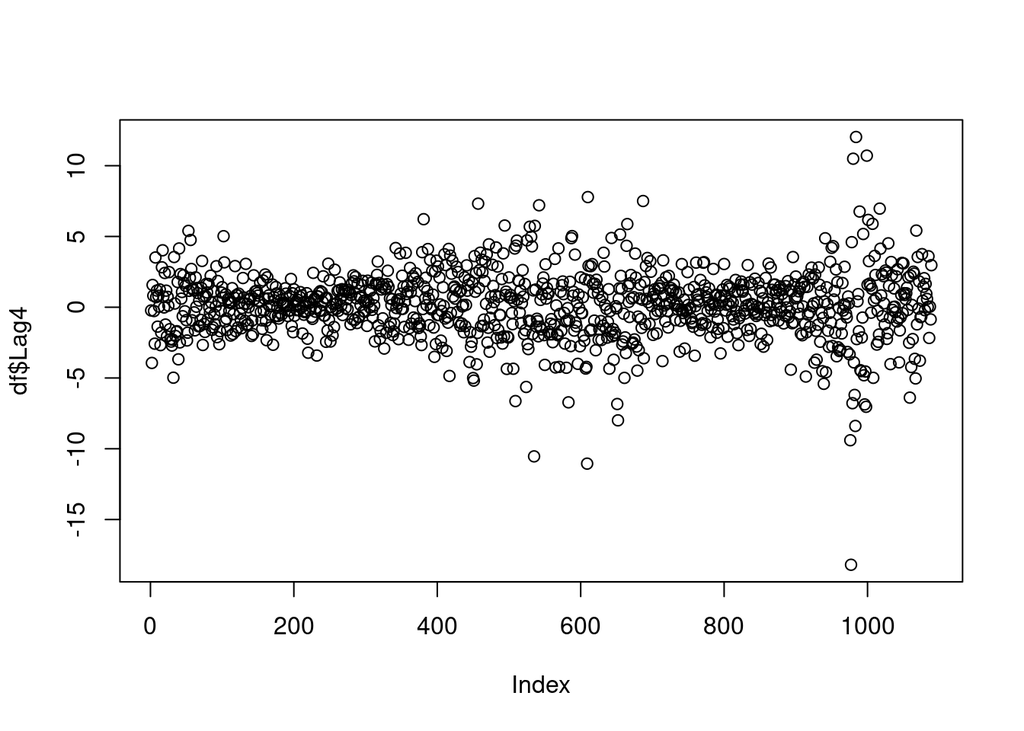

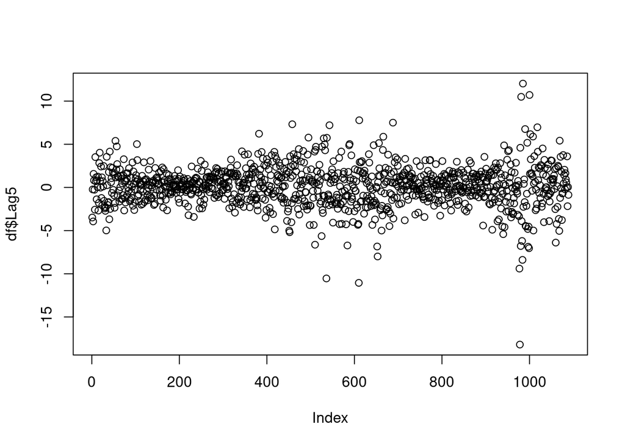

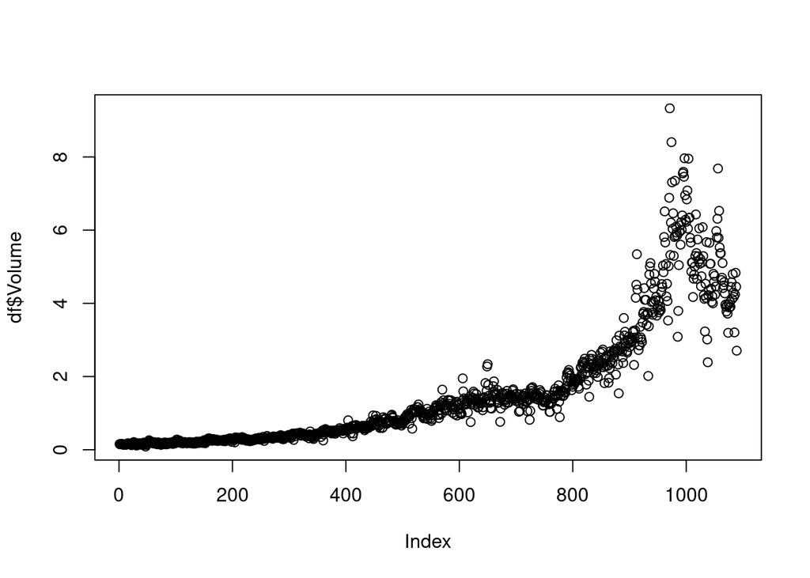

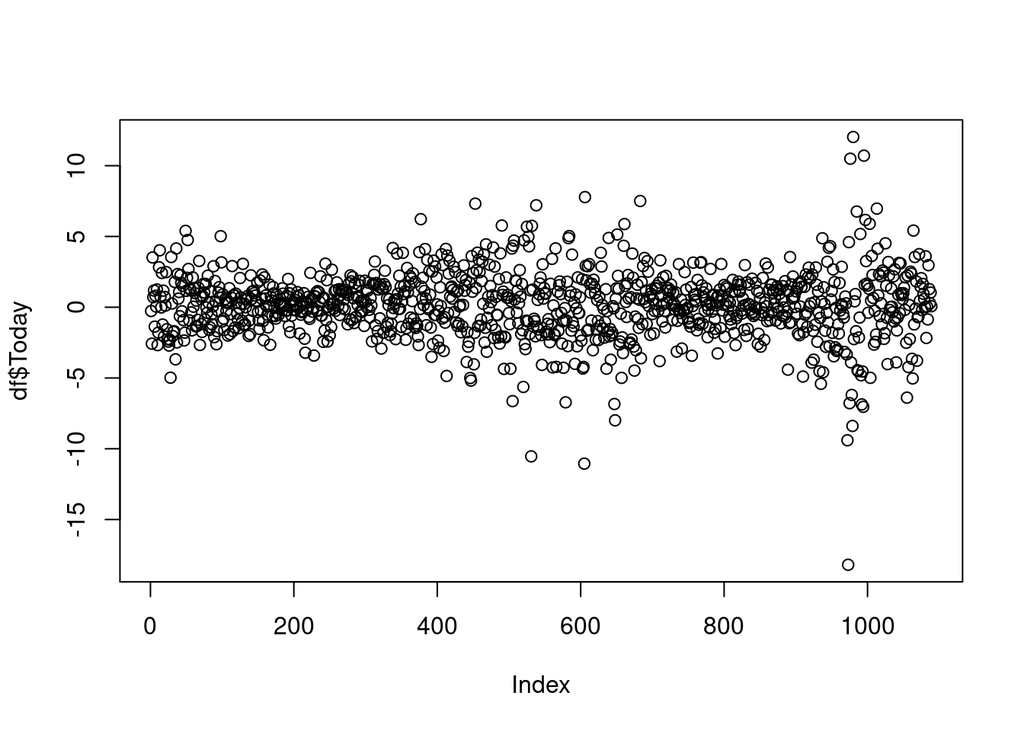

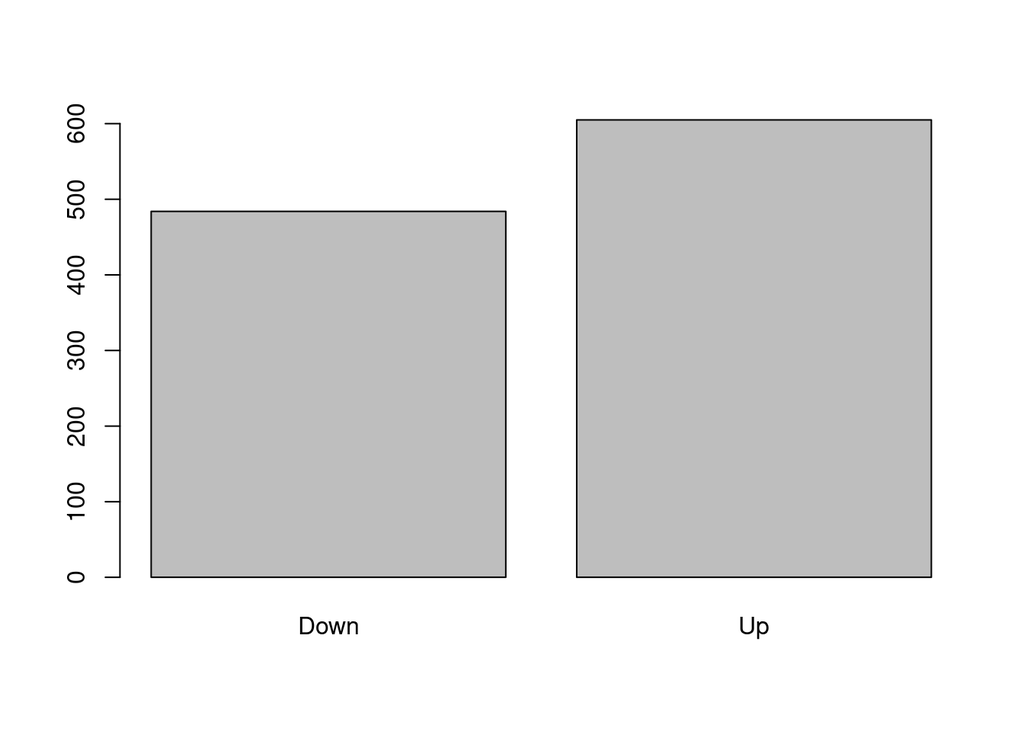

[output not shown]

```
##
## Call:
## glm(formula = Direction ~ Lag1 + Lag2 + Lag3 + Lag4 + Lag5 +
##     Volume, family = "binomial", data = Weekly)
##
## Deviance Residuals:
##     Min       1Q   Median       3Q      Max
## -1.6949  -1.2565   0.9913   1.0849   1.4579
##
## Coefficients:
##             Estimate Std. Error z value Pr(>|z|)
## (Intercept)  0.26686    0.08593   3.106   0.0019 **
## Lag1        -0.04127    0.02641  -1.563   0.1181
## Lag2         0.05844    0.02686   2.175   0.0296 *
## Lag3        -0.01606    0.02666  -0.602   0.5469
## Lag4        -0.02779    0.02646  -1.050   0.2937
## Lag5        -0.01447    0.02638  -0.549   0.5833
## Volume      -0.02274    0.03690  -0.616   0.5377
## ---
## Signif. codes:  0 '***' 0.001 '**' 0.01 '*' 0.05 '.' 0.1 ' ' 1
##
## (Dispersion parameter for binomial family taken to be 1)
##
##     Null deviance: 1496.2  on 1088  degrees of freedom
## Residual deviance: 1486.4  on 1082  degrees of freedom
## AIC: 1500.4
##
## Number of Fisher Scoring iterations: 4
```

```
## [1] "Lag 2 appears to be statistically significant."
```

```
##
##                  Down  Up
##   Down (guessed)   54  48
##   Up (guessed)    430 557
```

```
## [1] 0.5610652
```

[output not shown]

4.8.13.d refer to lab3

```
##
##               Down Up
##   Down (pred)    9  5
##   Up (pred)     34 56
```

```
## [1] 0.625
```

4.8.13.e:

```
##
## ldapredict Down Up
##       Down    9  5
##       Up     34 56
```

```
## [1] 0.625
```

4.8.13.f:

```
##
## qdapred Down Up
##    Down    0  0
##    Up     43 61
```

```
## [1] 0.5865385
```

4.8.13.g:

```
##
## knnfit Down Up
##   Down   21 30
##   Up     22 31
```

[output not shown]

4.8.13.h:

```
##
## bayesspread Down Up
##        Down   27 29
##        Up     16 32
```

```
## [1] 0.5673077
```

4.8.13.j:

```
##
## knnfit2 Down Up
##    Down   18 26
##    Up     25 35
```

```
## [1] 0.5096154
```

[output not shown]

```
## [1] 0.625
```

[output not shown]

```
## [1] 0.5865385
```